# Udacity Data Analyst Nanodegree

## Final Project Wrangling and EDA

## Loan Data from Prosper

This data set contains 113,937 loans with 81 variables on each loan, including loan amount, borrower rate (or interest rate), current loan status, borrower income, and many others. The data was provided by udacity as part of their data visualisation project. The data dictionary can be found at https://docs.google.com/spreadsheets/d/1gDyi_L4UvIrLTEC6Wri5nbaMmkGmLQBk-Yx3z0XDEtI/edit#gid=0

```python
import numpy as np # linear algebra
import pandas as pd # data processing, CSV file I/O (e.g. pd.read_csv)
import matplotlib.pyplot as plt
%matplotlib inline
# Input data files are available in the "../input/" directory.
# For example, running this (by clicking run or pressing Shift+Enter) will list the files in the input directory

import os
print(os.listdir("../input"))

# Any results you write to the current directory are saved as output.
```

```
['prosperLoanData.csv']
```

```python
df = pd.read_csv('../input/prosperLoanData.csv')
```

```python
df.head()
```

|  | ListingKey | ListingNumber | ListingCreationDate | CreditGrade | Term | LoanStatus | ClosedDate | BorrowerAPR | BorrowerRate | LenderYield | EstimatedEffectiveYield | EstimatedLoss | EstimatedReturn | ProsperRating (numeric) | ProsperRating (Alpha) | ProsperScore | ListingCategory (numeric) | BorrowerState | Occupation | EmploymentStatus | EmploymentStatusDuration | IsBorrowerHomeowner | CurrentlyInGroup | GroupKey | DateCreditPulled | CreditScoreRangeLower | CreditScoreRangeUpper | FirstRecordedCreditLine | CurrentCreditLines | … |
| --- | --- | --- | --- | --- | --- | --- | --- | --- | --- | --- | --- | --- | --- | --- | --- | --- | --- | --- | --- | --- | --- | --- | --- | --- | --- | --- | --- | --- | --- | --- |
| 0 | 1021339766868145413AB3B | 193129 | 2007-08-26 19:09:29.263000000 | C | 36 | Completed | 2009-08-14 00:00:00 | 0.16516 | 0.1580 | 0.1380 | NaN | NaN | NaN | NaN | NaN | NaN | 0 | CO | Other | Self-employed | 2.0 | True | True | NaN | 2007-08-26 18:41:46.780000000 | 640.0 | 659.0 | 2001-10-11 00:00:00 | 5.0 | … |
| 1 | 10273602499503308B223C1 | 1209647 | 2014-02-27 08:28:07.900000000 | NaN | 36 | Current | NaN | 0.12016 | 0.0920 | 0.0820 | 0.07960 | 0.0249 | 0.05470 | 6.0 | A | 7.0 | 2 | CO | Professional | Employed | 44.0 | False | False | NaN | 2014-02-27 08:28:14 | 680.0 | 699.0 | 1996-03-18 00:00:00 | 14.0 | … |
| 2 | 0EE9337825851032864889A | 81716 | 2007-01-05 15:00:47.090000000 | HR | 36 | Completed | 2009-12-17 00:00:00 | 0.28269 | 0.2750 | 0.2400 | NaN | NaN | NaN | NaN | NaN | NaN | 0 | GA | Other | Not available | NaN | False | True | 783C3371218786870A73D20 | 2007-01-02 14:09:10.060000000 | 480.0 | 499.0 | 2002-07-27 00:00:00 | NaN | … |
| 3 | 0EF5356002482715299901A | 658116 | 2012-10-22 11:02:35.010000000 | NaN | 36 | Current | NaN | 0.12528 | 0.0974 | 0.0874 | 0.08490 | 0.0249 | 0.06000 | 6.0 | A | 9.0 | 16 | GA | Skilled Labor | Employed | 113.0 | True | False | NaN | 2012-10-22 11:02:32 | 800.0 | 819.0 | 1983-02-28 00:00:00 | 5.0 | … |
| 4 | 0F023589499656230C5E3E2 | 909464 | 2013-09-14 18:38:39.097000000 | NaN | 36 | Current | NaN | 0.24614 | 0.2085 | 0.1985 | 0.18316 | 0.0925 | 0.09066 | 3.0 | D | 4.0 | 2 | MN | Executive | Employed | 44.0 | True | False | NaN | 2013-09-14 18:38:44 | 680.0 | 699.0 | 2004-02-20 00:00:00 | 19.0 | … |

```python
df.info()
```

```
<class 'pandas.core.frame.DataFrame'>
RangeIndex: 113937 entries, 0 to 113936
Data columns (total 81 columns):
ListingKey                             113937 non-null object
ListingNumber                          113937 non-null int64
ListingCreationDate                    113937 non-null object
CreditGrade                            28953 non-null object
Term                                   113937 non-null int64
LoanStatus                             113937 non-null object
ClosedDate                             55089 non-null object
BorrowerAPR                            113912 non-null float64
BorrowerRate                           113937 non-null float64
LenderYield                            113937 non-null float64
EstimatedEffectiveYield                84853 non-null float64
EstimatedLoss                          84853 non-null float64
EstimatedReturn                        84853 non-null float64
ProsperRating (numeric)                84853 non-null float64
ProsperRating (Alpha)                  84853 non-null object
ProsperScore                           84853 non-null float64
ListingCategory (numeric)              113937 non-null int64
BorrowerState                          108422 non-null object
Occupation                             110349 non-null object
EmploymentStatus                       111682 non-null object
EmploymentStatusDuration               106312 non-null float64
IsBorrowerHomeowner                    113937 non-null bool
CurrentlyInGroup                       113937 non-null bool
GroupKey                               13341 non-null object
DateCreditPulled                       113937 non-null object
CreditScoreRangeLower                  113346 non-null float64
CreditScoreRangeUpper                  113346 non-null float64
FirstRecordedCreditLine                113240 non-null object
CurrentCreditLines                     106333 non-null float64
OpenCreditLines                        106333 non-null float64
TotalCreditLinespast7years             113240 non-null float64
OpenRevolvingAccounts                  113937 non-null int64
OpenRevolvingMonthlyPayment            113937 non-null float64
InquiriesLast6Months                   113240 non-null float64
TotalInquiries                         112778 non-null float64
CurrentDelinquencies                   113240 non-null float64
AmountDelinquent                       106315 non-null float64
```

[output cut: 31 more lines]

```
LP_CustomerPayments                    113937 non-null float64
LP_CustomerPrincipalPayments           113937 non-null float64
LP_InterestandFees                     113937 non-null float64
LP_ServiceFees                         113937 non-null float64
LP_CollectionFees                      113937 non-null float64
LP_GrossPrincipalLoss                  113937 non-null float64
LP_NetPrincipalLoss                    113937 non-null float64
LP_NonPrincipalRecoverypayments        113937 non-null float64
PercentFunded                          113937 non-null float64
Recommendations                        113937 non-null int64
InvestmentFromFriendsCount             113937 non-null int64
InvestmentFromFriendsAmount            113937 non-null float64
Investors                              113937 non-null int64
dtypes: bool(3), float64(50), int64(11), object(17)
memory usage: 68.1+ MB
```

Lets first check the data for any bias in classes.

```python
df['LoanStatus'].value_counts()
```

```
Current                   56576
Completed                 38074
Chargedoff                11992
Defaulted                  5018
Past Due (1-15 days)        806
Past Due (31-60 days)       363
Past Due (61-90 days)       313
Past Due (91-120 days)      304
Past Due (16-30 days)       265
FinalPaymentInProgress      205
Past Due (>120 days)         16
Cancelled                     5
Name: LoanStatus, dtype: int64
```

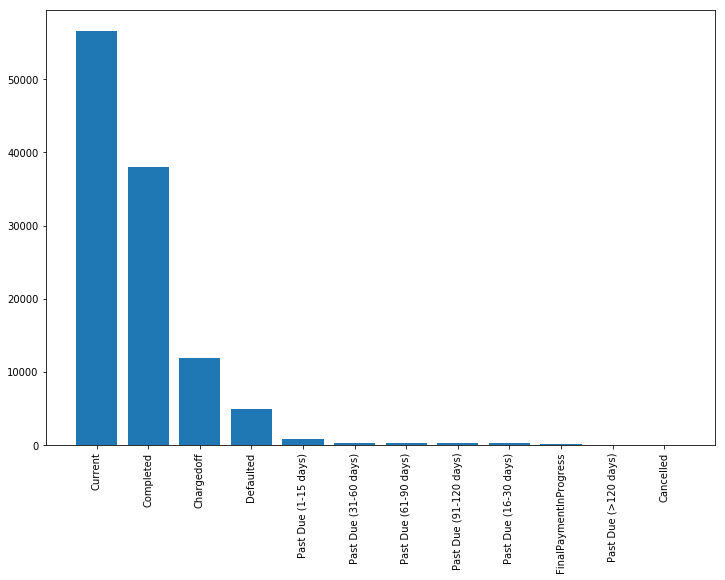

```python
label_counts = df['LoanStatus'].value_counts()
fig, ax1 = plt.subplots(1,1,figsize = (12, 8))
ax1.bar(np.arange(len(label_counts))+0.5, label_counts)
ax1.set_xticks(np.arange(len(label_counts))+0.5)
_ = ax1.set_xticklabels(label_counts.index, rotation = 90)
```

From the data we can see an obvious trend, that current and completed are the most common type of the loans in this category. Whatever analysis that I can do on this would be mostly on current or completed loan statuses. It should be noted that there are 6 Past Due Counts, which total upto 2067.

Let's do some cleaning on the data.

```python
df_clean = df
```

### Change the timestamp to a Year Time

```python
cols = ['ListingCreationDate','FirstRecordedCreditLine','DateCreditPulled','ClosedDate']
for col in cols:
    df_clean[col] = pd.to_datetime(df_clean[col])
    df_clean[col+'Actual'] = df_clean[col].dt.date
    print(df_clean[col+'Actual'].head())
```

```
0    2007-08-26
1    2014-02-27
2    2007-01-05
3    2012-10-22
4    2013-09-14
Name: ListingCreationDateActual, dtype: object
0    2001-10-11
1    1996-03-18
2    2002-07-27
3    1983-02-28
4    2004-02-20
Name: FirstRecordedCreditLineActual, dtype: object
0    2007-08-26
1    2014-02-27
2    2007-01-02
3    2012-10-22
4    2013-09-14
Name: DateCreditPulledActual, dtype: object
0    2009-08-14
1           NaT
2    2009-12-17
3           NaT
4           NaT
Name: ClosedDateActual, dtype: object
```

Let's check the missing values and try to fill any, if possible

```python
df.describe()
```

|  | ListingNumber | Term | BorrowerAPR | BorrowerRate | LenderYield | EstimatedEffectiveYield | EstimatedLoss | EstimatedReturn | ProsperRating (numeric) | ProsperScore | ListingCategory (numeric) | EmploymentStatusDuration | CreditScoreRangeLower | CreditScoreRangeUpper | CurrentCreditLines | OpenCreditLines | TotalCreditLinespast7years | OpenRevolvingAccounts | OpenRevolvingMonthlyPayment | InquiriesLast6Months | TotalInquiries | CurrentDelinquencies | AmountDelinquent | DelinquenciesLast7Years | PublicRecordsLast10Years | PublicRecordsLast12Months | RevolvingCreditBalance | BankcardUtilization | AvailableBankcardCredit | … |
| --- | --- | --- | --- | --- | --- | --- | --- | --- | --- | --- | --- | --- | --- | --- | --- | --- | --- | --- | --- | --- | --- | --- | --- | --- | --- | --- | --- | --- | --- | --- |
| count | 1.139370e+05 | 113937.000000 | 113912.000000 | 113937.000000 | 113937.000000 | 84853.000000 | 84853.000000 | 84853.000000 | 84853.000000 | 84853.000000 | 113937.000000 | 106312.000000 | 113346.000000 | 113346.000000 | 106333.000000 | 106333.000000 | 113240.000000 | 113937.00000 | 113937.000000 | 113240.000000 | 112778.000000 | 113240.000000 | 106315.000000 | 112947.000000 | 113240.000000 | 106333.000000 | 1.063330e+05 | 106333.000000 | 106393.000000 | … |
| mean | 6.278857e+05 | 40.830248 | 0.218828 | 0.192764 | 0.182701 | 0.168661 | 0.080306 | 0.096068 | 4.072243 | 5.950067 | 2.774209 | 96.071582 | 685.567731 | 704.567731 | 10.317192 | 9.260164 | 26.754539 | 6.96979 | 398.292161 | 1.435085 | 5.584405 | 0.592052 | 984.507059 | 4.154984 | 0.312646 | 0.015094 | 1.759871e+04 | 0.561309 | 11210.225447 | … |
| std | 3.280762e+05 | 10.436212 | 0.080364 | 0.074818 | 0.074516 | 0.068467 | 0.046764 | 0.030403 | 1.673227 | 2.376501 | 3.996797 | 94.480605 | 66.458275 | 66.458275 | 5.457866 | 5.022644 | 13.637871 | 4.63097 | 447.159711 | 2.437507 | 6.429946 | 1.978707 | 7158.270157 | 10.160216 | 0.727868 | 0.154092 | 3.293640e+04 | 0.317918 | 19818.361309 | … |
| min | 4.000000e+00 | 12.000000 | 0.006530 | 0.000000 | -0.010000 | -0.182700 | 0.004900 | -0.182700 | 1.000000 | 1.000000 | 0.000000 | 0.000000 | 0.000000 | 19.000000 | 0.000000 | 0.000000 | 2.000000 | 0.00000 | 0.000000 | 0.000000 | 0.000000 | 0.000000 | 0.000000 | 0.000000 | 0.000000 | 0.000000 | 0.000000e+00 | 0.000000 | 0.000000 | … |
| 25% | 4.009190e+05 | 36.000000 | 0.156290 | 0.134000 | 0.124200 | 0.115670 | 0.042400 | 0.074080 | 3.000000 | 4.000000 | 1.000000 | 26.000000 | 660.000000 | 679.000000 | 7.000000 | 6.000000 | 17.000000 | 4.00000 | 114.000000 | 0.000000 | 2.000000 | 0.000000 | 0.000000 | 0.000000 | 0.000000 | 0.000000 | 3.121000e+03 | 0.310000 | 880.000000 | … |
| 50% | 6.005540e+05 | 36.000000 | 0.209760 | 0.184000 | 0.173000 | 0.161500 | 0.072400 | 0.091700 | 4.000000 | 6.000000 | 1.000000 | 67.000000 | 680.000000 | 699.000000 | 10.000000 | 9.000000 | 25.000000 | 6.00000 | 271.000000 | 1.000000 | 4.000000 | 0.000000 | 0.000000 | 0.000000 | 0.000000 | 0.000000 | 8.549000e+03 | 0.600000 | 4100.000000 | … |
| 75% | 8.926340e+05 | 36.000000 | 0.283810 | 0.250000 | 0.240000 | 0.224300 | 0.112000 | 0.116600 | 5.000000 | 8.000000 | 3.000000 | 137.000000 | 720.000000 | 739.000000 | 13.000000 | 12.000000 | 35.000000 | 9.00000 | 525.000000 | 2.000000 | 7.000000 | 0.000000 | 0.000000 | 3.000000 | 0.000000 | 0.000000 | 1.952100e+04 | 0.840000 | 13180.000000 | … |
| max | 1.255725e+06 | 60.000000 | 0.512290 | 0.497500 | 0.492500 | 0.319900 | 0.366000 | 0.283700 | 7.000000 | 11.000000 | 20.000000 | 755.000000 | 880.000000 | 899.000000 | 59.000000 | 54.000000 | 136.000000 | 51.00000 | 14985.000000 | 105.000000 | 379.000000 | 83.000000 | 463881.000000 | 99.000000 | 38.000000 | 20.000000 | 1.435667e+06 | 5.950000 | 646285.000000 | … |

```python
df_clean.isnull().sum()[:40]
```

```
ListingKey                          0
ListingNumber                       0
ListingCreationDate                 0
CreditGrade                     84984
Term                                0
LoanStatus                          0
ClosedDate                      58848
BorrowerAPR                        25
BorrowerRate                        0
LenderYield                         0
EstimatedEffectiveYield         29084
EstimatedLoss                   29084
EstimatedReturn                 29084
ProsperRating (numeric)         29084
ProsperRating (Alpha)           29084
ProsperScore                    29084
ListingCategory (numeric)           0
BorrowerState                    5515
Occupation                       3588
EmploymentStatus                 2255
EmploymentStatusDuration         7625
IsBorrowerHomeowner                 0
CurrentlyInGroup                    0
GroupKey                       100596
DateCreditPulled                    0
CreditScoreRangeLower             591
CreditScoreRangeUpper             591
FirstRecordedCreditLine           697
CurrentCreditLines               7604
OpenCreditLines                  7604
TotalCreditLinespast7years        697
OpenRevolvingAccounts               0
OpenRevolvingMonthlyPayment         0
InquiriesLast6Months              697
TotalInquiries                   1159
CurrentDelinquencies              697
AmountDelinquent                 7622
DelinquenciesLast7Years           990
PublicRecordsLast10Years          697
PublicRecordsLast12Months        7604
dtype: int64
```

```python
df_clean.isnull().sum()[40:]
```

```
RevolvingCreditBalance                  7604
BankcardUtilization                     7604
AvailableBankcardCredit                 7544
TotalTrades                             7544
TradesNeverDelinquent (percentage)      7544
TradesOpenedLast6Months                 7544
DebtToIncomeRatio                       8554
IncomeRange                                0
IncomeVerifiable                           0
StatedMonthlyIncome                        0
LoanKey                                    0
TotalProsperLoans                      91852
TotalProsperPaymentsBilled             91852
OnTimeProsperPayments                  91852
ProsperPaymentsLessThanOneMonthLate    91852
ProsperPaymentsOneMonthPlusLate        91852
ProsperPrincipalBorrowed               91852
ProsperPrincipalOutstanding            91852
ScorexChangeAtTimeOfListing            95009
LoanCurrentDaysDelinquent                  0
LoanFirstDefaultedCycleNumber          96985
LoanMonthsSinceOrigination                 0
LoanNumber                                 0
LoanOriginalAmount                         0
LoanOriginationDate                        0
LoanOriginationQuarter                     0
MemberKey                                  0
MonthlyLoanPayment                         0
LP_CustomerPayments                        0
LP_CustomerPrincipalPayments               0
LP_InterestandFees                         0
LP_ServiceFees                             0
LP_CollectionFees                          0
LP_GrossPrincipalLoss                      0
LP_NetPrincipalLoss                        0
LP_NonPrincipalRecoverypayments            0
PercentFunded                              0
Recommendations                            0
InvestmentFromFriendsCount                 0
InvestmentFromFriendsAmount                0
Investors                                  0
ListingCreationDateActual                  0
FirstRecordedCreditLineActual            697
DateCreditPulledActual                     0
ClosedDateActual                       58848
dtype: int64
```

- The Credit rating that was assigned at the time the listing went live. Applicable for listings pre-2009 period and will only be populated for those listings.
- Closed Date, and by default, ClosedDateActual, is applicable for Cancelled, Completed, Chargedoff and Defaulted loan statuses only, so there are missing values.
- Borrower APR: There is no reason for the missing values, hence, the rows with the missing values will be removed.
- EstimatedEffectiveYield, EstimatedLoss, EstimatedReturn, ProsperRating (numeric), ProsperRating (Alpha), ProsperScore all have missing values because they are only applicable for loans after july 2009.
- Group Key is only filled if the borrower does has a group affiliation.
- CreditScoreRangeLower, CreditScoreRangeUpper, FirstRecordedCreditLine once again has missing data which can be simply removed.
- TotalProsperLoans, TotalProsperPaymentsBilled, OnTimeProsperPayments, ProsperPaymentsLessThanOneMonthLate, ProsperPaymentsOneMonthPlusLate, ProsperPrincipalBorrowed, ProsperPrincipalOutstanding are all to do with Prosper payments, and the commitment of paying loans. All missing information means there were no prior loans.
- ScorexChangeAtTimeOfListing : once again null values indicate that the borrower had no prior loans
- LoanFirstDefaultedCycleNumber shows the cycle the loan was charged off. If the loan has not charged off the value will be null, thus explaining the nulls.
- Change state abbr. to state names for better analysis
- Separate the data to pre-crisis and post-crisis to explain the Nulls better.

```python
#drop all those columns with primary keys
df_clean = df_clean.drop(columns = ['ListingNumber','GroupKey','LoanKey','OpenRevolvingAccounts',
               'MemberKey','ListingCreationDate','FirstRecordedCreditLine','DateCreditPulled','ClosedDate'])
```

```python
# remove the very few columns with Nulls.
cols = ['BorrowerAPR','CreditScoreRangeLower','CreditScoreRangeUpper','FirstRecordedCreditLineActual']
for col in cols:
    #remove
    df_clean = df_clean[~df_clean[col].isnull()]
    #check
    print(df_clean[col].isnull().sum())
```

```
0
0
0
0
```

```python
df_clean.sample(5)
```

|  | ListingKey | CreditGrade | Term | LoanStatus | BorrowerAPR | BorrowerRate | LenderYield | EstimatedEffectiveYield | EstimatedLoss | EstimatedReturn | ProsperRating (numeric) | ProsperRating (Alpha) | ProsperScore | ListingCategory (numeric) | BorrowerState | Occupation | EmploymentStatus | EmploymentStatusDuration | IsBorrowerHomeowner | CurrentlyInGroup | CreditScoreRangeLower | CreditScoreRangeUpper | CurrentCreditLines | OpenCreditLines | TotalCreditLinespast7years | OpenRevolvingMonthlyPayment | InquiriesLast6Months | TotalInquiries | CurrentDelinquencies | … |
| --- | --- | --- | --- | --- | --- | --- | --- | --- | --- | --- | --- | --- | --- | --- | --- | --- | --- | --- | --- | --- | --- | --- | --- | --- | --- | --- | --- | --- | --- | --- |
| 74046 | 8D8E3402123041359BC9650 | AA | 36 | Chargedoff | 0.11485 | 0.1079 | 0.1029 | NaN | NaN | NaN | NaN | NaN | NaN | 0 | FL | Other | Self-employed | 8.0 | True | False | 800.0 | 819.0 | 14.0 | 12.0 | 15.0 | 54.0 | 0.0 | 7.0 | 0.0 | … |
| 91427 | 71BD3406543315813A8BFF5 | B | 36 | Completed | 0.19730 | 0.1900 | 0.1800 | NaN | NaN | NaN | NaN | NaN | NaN | 0 | IN | Other | Full-time | 23.0 | True | False | 680.0 | 699.0 | 16.0 | 16.0 | 47.0 | 1927.0 | 2.0 | 7.0 | 0.0 | … |
| 47547 | E5BE3544554830459059886 | NaN | 60 | Completed | 0.24702 | 0.2220 | 0.2120 | 0.207 | 0.0650 | 0.1420 | 4.0 | C | 3.0 | 16 | CA | Fireman | Employed | 189.0 | False | False | 680.0 | 699.0 | 10.0 | 9.0 | 27.0 | 268.0 | 1.0 | 9.0 | 0.0 | … |
| 35617 | 68E63519588848774672EA6 | NaN | 12 | Completed | 0.34105 | 0.2499 | 0.2399 | 0.234 | 0.1120 | 0.1220 | 3.0 | D | 6.0 | 3 | DC | Other | Employed | 41.0 | False | False | 660.0 | 679.0 | 3.0 | 2.0 | 4.0 | 15.0 | 0.0 | 1.0 | 0.0 | … |
| 8161 | A5343560491545658681106 | NaN | 12 | Completed | 0.18192 | 0.1246 | 0.1146 | 0.108 | 0.0574 | 0.0506 | 5.0 | B | 5.0 | 7 | AZ | Other | Employed | 55.0 | False | False | 680.0 | 699.0 | 10.0 | 8.0 | 26.0 | 297.0 | 0.0 | 4.0 | 0.0 | … |

```python
#change state aabr
states = {
        'AK': 'Alaska',
        'AL': 'Alabama',
        'AR': 'Arkansas',
        'AS': 'American Samoa',
        'AZ': 'Arizona',
        'CA': 'California',
        'CO': 'Colorado',
        'CT': 'Connecticut',
        'DC': 'District of Columbia',
        'DE': 'Delaware',
        'FL': 'Florida',
        'GA': 'Georgia',
        'GU': 'Guam',
        'HI': 'Hawaii',
        'IA': 'Iowa',
        'ID': 'Idaho',
        'IL': 'Illinois',
        'IN': 'Indiana',
        'KS': 'Kansas',
        'KY': 'Kentucky',
        'LA': 'Louisiana',
        'MA': 'Massachusetts',
        'MD': 'Maryland',
        'ME': 'Maine',
        'MI': 'Michigan',
        'MN': 'Minnesota',
        'MO': 'Missouri',
        'MP': 'Northern Mariana Islands',
        'MS': 'Mississippi',
        'MT': 'Montana',
        'NA': 'National',
        'NC': 'North Carolina',
        'ND': 'North Dakota',
        'NE': 'Nebraska',
        'NH': 'New Hampshire',
        'NJ': 'New Jersey',
        'NM': 'New Mexico',
        'NV': 'Nevada',
        'NY': 'New York',
        'OH': 'Ohio',
        'OK': 'Oklahoma',
        'OR': 'Oregon',
        'PA': 'Pennsylvania',
        'PR': 'Puerto Rico',
        'RI': 'Rhode Island',
        'SC': 'South Carolina',
        'SD': 'South Dakota',
        'TN': 'Tennessee',
        'TX': 'Texas',
        'UT': 'Utah',
        'VA': 'Virginia',
        'VI': 'Virgin Islands',
        'VT': 'Vermont',
        'WA': 'Washington',
        'WI': 'Wisconsin',
        'WV': 'West Virginia',
        'WY': 'Wyoming'
}

df_clean['BorrowerState'] = df_clean['BorrowerState'].apply(lambda x: states[x] if x in states.keys() else 'Other')
df_clean['BorrowerState'] = df_clean['BorrowerState'].fillna('Other')
df_clean['BorrowerState'].value_counts()
```

```
California              14698
Texas                    6837
New York                 6727
Florida                  6715
Illinois                 5915
Georgia                  5002
Other                    4890
Ohio                     4197
Michigan                 3590
Virginia                 3278
New Jersey               3097
North Carolina           3084
Washington               3048
Pennsylvania             2971
Maryland                 2821
Missouri                 2608
Minnesota                2317
Massachusetts            2241
Colorado                 2209
Indiana                  2076
Arizona                  1901
Wisconsin                1840
Oregon                   1817
Tennessee                1737
Alabama                  1676
Connecticut              1627
South Carolina           1122
Nevada                   1090
Kansas                   1062
Kentucky                  983
Oklahoma                  971
Louisiana                 953
Utah                      876
Arkansas                  855
Mississippi               787
Nebraska                  674
Idaho                     598
New Hampshire             551
New Mexico                471
Rhode Island              435
Hawaii                    409
West Virginia             390
District of Columbia      382
Montana                   329
Delaware                  300
Vermont                   207
Alaska                    200
South Dakota              189
Iowa                      186
Wyoming                   150
Maine                      99
North Dakota               52
Name: BorrowerState, dtype: int64
```

```python
#Occupation, EmploymentStatus, EmploymentStatusDuration
df_clean['Occupation'] = df_clean['Occupation'].fillna('Other')
df_clean['EmploymentStatus'] = df_clean['EmploymentStatus'].fillna('Not available')
df_clean['EmploymentStatusDuration'] = df_clean['EmploymentStatusDuration'].fillna(0)
df_clean['TotalProsperLoans'] = df_clean['TotalProsperLoans'].fillna(0)
```

```python
df_clean.isnull().sum()[:40]
```

```
ListingKey                                0
CreditGrade                           84984
Term                                      0
LoanStatus                                0
BorrowerAPR                               0
BorrowerRate                              0
LenderYield                               0
EstimatedEffectiveYield               28387
EstimatedLoss                         28387
EstimatedReturn                       28387
ProsperRating (numeric)               28387
ProsperRating (Alpha)                 28387
ProsperScore                          28387
ListingCategory (numeric)                 0
BorrowerState                             0
Occupation                                0
EmploymentStatus                          0
EmploymentStatusDuration                  0
IsBorrowerHomeowner                       0
CurrentlyInGroup                          0
CreditScoreRangeLower                     0
CreditScoreRangeUpper                     0
CurrentCreditLines                     6927
OpenCreditLines                        6927
TotalCreditLinespast7years                0
OpenRevolvingMonthlyPayment               0
InquiriesLast6Months                      0
TotalInquiries                          561
CurrentDelinquencies                      0
AmountDelinquent                       6925
DelinquenciesLast7Years                 293
PublicRecordsLast10Years                  0
PublicRecordsLast12Months              6927
RevolvingCreditBalance                 6927
BankcardUtilization                    6927
AvailableBankcardCredit                6869
TotalTrades                            6869
TradesNeverDelinquent (percentage)     6869
TradesOpenedLast6Months                6869
DebtToIncomeRatio                      8442
dtype: int64
```

```python
df_clean.isnull().sum()[40:]
```

```
IncomeRange                                0
IncomeVerifiable                           0
StatedMonthlyIncome                        0
TotalProsperLoans                          0
TotalProsperPaymentsBilled             91155
OnTimeProsperPayments                  91155
ProsperPaymentsLessThanOneMonthLate    91155
ProsperPaymentsOneMonthPlusLate        91155
ProsperPrincipalBorrowed               91155
ProsperPrincipalOutstanding            91155
ScorexChangeAtTimeOfListing            94312
LoanCurrentDaysDelinquent                  0
LoanFirstDefaultedCycleNumber          96523
LoanMonthsSinceOrigination                 0
LoanNumber                                 0
LoanOriginalAmount                         0
LoanOriginationDate                        0
LoanOriginationQuarter                     0
MonthlyLoanPayment                         0
LP_CustomerPayments                        0
LP_CustomerPrincipalPayments               0
LP_InterestandFees                         0
LP_ServiceFees                             0
LP_CollectionFees                          0
LP_GrossPrincipalLoss                      0
LP_NetPrincipalLoss                        0
LP_NonPrincipalRecoverypayments            0
PercentFunded                              0
Recommendations                            0
InvestmentFromFriendsCount                 0
InvestmentFromFriendsAmount                0
Investors                                  0
ListingCreationDateActual                  0
FirstRecordedCreditLineActual              0
DateCreditPulledActual                     0
ClosedDateActual                       58848
dtype: int64
```

```python
#separate between pre crisis and post-crisis
import datetime
split_date = datetime.date(2009,7,31)
df_pre = df_clean.loc[df_clean['ListingCreationDateActual'] <= split_date]
df_post = df_clean.loc[df_clean['ListingCreationDateActual'] > split_date]
```

```python
df_pre.info()
```

```
<class 'pandas.core.frame.DataFrame'>
Int64Index: 28568 entries, 0 to 113927
Data columns (total 76 columns):
ListingKey                             28568 non-null object
CreditGrade                            28256 non-null object
Term                                   28568 non-null int64
LoanStatus                             28568 non-null object
BorrowerAPR                            28568 non-null float64
BorrowerRate                           28568 non-null float64
LenderYield                            28568 non-null float64
EstimatedEffectiveYield                181 non-null float64
EstimatedLoss                          181 non-null float64
EstimatedReturn                        181 non-null float64
ProsperRating (numeric)                181 non-null float64
ProsperRating (Alpha)                  181 non-null object
ProsperScore                           181 non-null float64
ListingCategory (numeric)              28568 non-null int64
BorrowerState                          28568 non-null object
Occupation                             28568 non-null object
EmploymentStatus                       28568 non-null object
EmploymentStatusDuration               28568 non-null float64
IsBorrowerHomeowner                    28568 non-null bool
CurrentlyInGroup                       28568 non-null bool
CreditScoreRangeLower                  28568 non-null float64
CreditScoreRangeUpper                  28568 non-null float64
CurrentCreditLines                     21641 non-null float64
OpenCreditLines                        21641 non-null float64
TotalCreditLinespast7years             28568 non-null float64
OpenRevolvingMonthlyPayment            28568 non-null float64
InquiriesLast6Months                   28568 non-null float64
TotalInquiries                         28007 non-null float64
CurrentDelinquencies                   28568 non-null float64
AmountDelinquent                       21643 non-null float64
DelinquenciesLast7Years                28275 non-null float64
PublicRecordsLast10Years               28568 non-null float64
PublicRecordsLast12Months              21641 non-null float64
RevolvingCreditBalance                 21641 non-null float64
BankcardUtilization                    21641 non-null float64
AvailableBankcardCredit                21699 non-null float64
TotalTrades                            21699 non-null float64
```

[output cut: 26 more lines]

```
LP_CollectionFees                      28568 non-null float64
LP_GrossPrincipalLoss                  28568 non-null float64
LP_NetPrincipalLoss                    28568 non-null float64
LP_NonPrincipalRecoverypayments        28568 non-null float64
PercentFunded                          28568 non-null float64
Recommendations                        28568 non-null int64
InvestmentFromFriendsCount             28568 non-null int64
InvestmentFromFriendsAmount            28568 non-null float64
Investors                              28568 non-null int64
ListingCreationDateActual              28568 non-null object
FirstRecordedCreditLineActual          28568 non-null object
DateCreditPulledActual                 28568 non-null object
ClosedDateActual                       28568 non-null object
dtypes: bool(3), float64(50), int64(9), object(14)
memory usage: 16.2+ MB
```

```python
df_post.info()
```

```
<class 'pandas.core.frame.DataFrame'>
Int64Index: 84672 entries, 1 to 113936
Data columns (total 76 columns):
ListingKey                             84672 non-null object
CreditGrade                            0 non-null object
Term                                   84672 non-null int64
LoanStatus                             84672 non-null object
BorrowerAPR                            84672 non-null float64
BorrowerRate                           84672 non-null float64
LenderYield                            84672 non-null float64
EstimatedEffectiveYield                84672 non-null float64
EstimatedLoss                          84672 non-null float64
EstimatedReturn                        84672 non-null float64
ProsperRating (numeric)                84672 non-null float64
ProsperRating (Alpha)                  84672 non-null object
ProsperScore                           84672 non-null float64
ListingCategory (numeric)              84672 non-null int64
BorrowerState                          84672 non-null object
Occupation                             84672 non-null object
EmploymentStatus                       84672 non-null object
EmploymentStatusDuration               84672 non-null float64
IsBorrowerHomeowner                    84672 non-null bool
CurrentlyInGroup                       84672 non-null bool
CreditScoreRangeLower                  84672 non-null float64
CreditScoreRangeUpper                  84672 non-null float64
CurrentCreditLines                     84672 non-null float64
OpenCreditLines                        84672 non-null float64
TotalCreditLinespast7years             84672 non-null float64
OpenRevolvingMonthlyPayment            84672 non-null float64
InquiriesLast6Months                   84672 non-null float64
TotalInquiries                         84672 non-null float64
CurrentDelinquencies                   84672 non-null float64
AmountDelinquent                       84672 non-null float64
DelinquenciesLast7Years                84672 non-null float64
PublicRecordsLast10Years               84672 non-null float64
PublicRecordsLast12Months              84672 non-null float64
RevolvingCreditBalance                 84672 non-null float64
BankcardUtilization                    84672 non-null float64
AvailableBankcardCredit                84672 non-null float64
TotalTrades                            84672 non-null float64
```

[output cut: 26 more lines]

```
LP_CollectionFees                      84672 non-null float64
LP_GrossPrincipalLoss                  84672 non-null float64
LP_NetPrincipalLoss                    84672 non-null float64
LP_NonPrincipalRecoverypayments        84672 non-null float64
PercentFunded                          84672 non-null float64
Recommendations                        84672 non-null int64
InvestmentFromFriendsCount             84672 non-null int64
InvestmentFromFriendsAmount            84672 non-null float64
Investors                              84672 non-null int64
ListingCreationDateActual              84672 non-null object
FirstRecordedCreditLineActual          84672 non-null object
DateCreditPulledActual                 84672 non-null object
ClosedDateActual                       25824 non-null object
dtypes: bool(3), float64(50), int64(9), object(14)
memory usage: 48.0+ MB
```

```python
df_pre.head()
```

|  | ListingKey | CreditGrade | Term | LoanStatus | BorrowerAPR | BorrowerRate | LenderYield | EstimatedEffectiveYield | EstimatedLoss | EstimatedReturn | ProsperRating (numeric) | ProsperRating (Alpha) | ProsperScore | ListingCategory (numeric) | BorrowerState | Occupation | EmploymentStatus | EmploymentStatusDuration | IsBorrowerHomeowner | CurrentlyInGroup | CreditScoreRangeLower | CreditScoreRangeUpper | CurrentCreditLines | OpenCreditLines | TotalCreditLinespast7years | OpenRevolvingMonthlyPayment | InquiriesLast6Months | TotalInquiries | CurrentDelinquencies | … |
| --- | --- | --- | --- | --- | --- | --- | --- | --- | --- | --- | --- | --- | --- | --- | --- | --- | --- | --- | --- | --- | --- | --- | --- | --- | --- | --- | --- | --- | --- | --- |
| 0 | 1021339766868145413AB3B | C | 36 | Completed | 0.16516 | 0.1580 | 0.1380 | NaN | NaN | NaN | NaN | NaN | NaN | 0 | Colorado | Other | Self-employed | 2.0 | True | True | 640.0 | 659.0 | 5.0 | 4.0 | 12.0 | 24.0 | 3.0 | 3.0 | 2.0 | … |
| 2 | 0EE9337825851032864889A | HR | 36 | Completed | 0.28269 | 0.2750 | 0.2400 | NaN | NaN | NaN | NaN | NaN | NaN | 0 | Georgia | Other | Not available | 0.0 | False | True | 480.0 | 499.0 | NaN | NaN | 3.0 | 0.0 | 0.0 | 1.0 | 1.0 | … |
| 11 | 0F1734025150298088A5F2B | C | 36 | Completed | 0.15033 | 0.1325 | 0.1225 | NaN | NaN | NaN | NaN | NaN | NaN | 0 | Other | Waiter/Waitress | Full-time | 19.0 | False | False | 640.0 | 659.0 | 2.0 | 2.0 | 10.0 | 40.0 | 3.0 | 5.0 | 3.0 | … |
| 17 | 0FDF336575182398852A8DC | AA | 36 | Chargedoff | 0.13202 | 0.1250 | 0.1175 | NaN | NaN | NaN | NaN | NaN | NaN | 0 | Other | Professional | Not available | 0.0 | True | True | 760.0 | 779.0 | NaN | NaN | 36.0 | 346.0 | 7.0 | 17.0 | 2.0 | … |
| 21 | 1017340630713945364DA6B | D | 36 | Completed | 0.21488 | 0.2075 | 0.1975 | NaN | NaN | NaN | NaN | NaN | NaN | 0 | Michigan | Professional | Full-time | 36.0 | False | True | 620.0 | 639.0 | 4.0 | 4.0 | 13.0 | 15.0 | 0.0 | 8.0 | 1.0 | … |

The separtaion makes sense becasue there's proper separation in the data. Pre-2009 and post-2009.

```python
df_pre.to_csv('pre_2009_data.csv', index=False)
df_post.to_csv('post_2009_data.csv', index=False)
```